# ADPS 17Z — Ćwiczenie 4

MR & KJ

December 9, 2017

# Przykład 1 – analiza wariancji

Wygeneruj 5 prób losowych z tego samego rozkładu normalnego o licznościach 25:

```r
n = 25; mi = 20; sigma = 1
y1 = rnorm(n, mi, sigma)
y2 = rnorm(n, mi, sigma)
y3 = rnorm(n, mi, sigma)
y4 = rnorm(n, mi, sigma)
y5 = rnorm(n, mi, sigma)
```

Scal dane w ramkę i wyświetl wykresy pudełkowe:

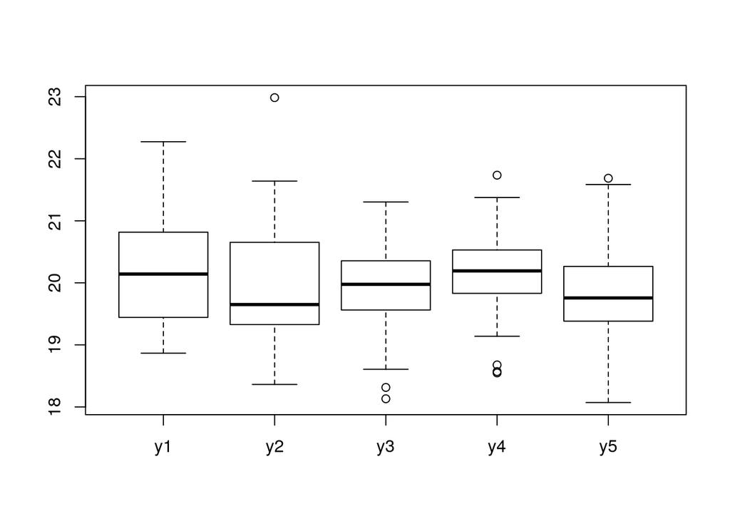

```r
y = cbind.data.frame(y1, y2, y3, y4, y5)
boxplot(y)
```

Przygotuj dane na potrzeby funkcji aov():

```r
dane_anova = stack(y)
names(dane_anova) <- c('dane', 'proba')
```

Sprawdź hipotezę o równości wariancji w próbach:

```r
bartlett.test(dane~proba, data = dane_anova)
```

```
##
##  Bartlett test of homogeneity of variances
##
## data:  dane by proba
## Bartlett's K-squared = 1.2934, df = 4, p-value = 0.8625
```

Przeprowadź analizę wariancji przy założeniu normalności rozkładów:

```r
aov_res = aov(dane~proba, data = dane_anova)
summary(aov_res)
```

```
##              Df Sum Sq Mean Sq F value Pr(>F)
## proba         4   1.71  0.4268   0.539  0.708
## Residuals   120  95.09  0.7924
```

Przeprowadź analizę wariancji bez założenia normalności rozkładów korzystając z testu Kruskala-Wallisa:

```r
kruskal.test(dane~proba, dane_anova)
```

```
##
##  Kruskal-Wallis rank sum test
##
## data:  dane by proba
## Kruskal-Wallis chi-squared = 2.3688, df = 4, p-value = 0.6683
```

Korzystając z metody Tukeya sprawdź, czy dla którejś z prób jej wartość średnia odbiega od wartości średnich w pozostałych próbach:

```r
Tukey_res = TukeyHSD(aov_res)
print(Tukey_res)
```

```
##   Tukey multiple comparisons of means
##     95% family-wise confidence level
##
## Fit: aov(formula = dane ~ proba, data = dane_anova)
##
## $proba
##              diff        lwr       upr     p adj
## y2-y1 -0.16387367 -0.8612283 0.5334810 0.9661796
## y3-y1 -0.31078710 -1.0081418 0.3865676 0.7313453
## y4-y1 -0.06440821 -0.7617629 0.6329465 0.9990442
## y5-y1 -0.26391423 -0.9612689 0.4334405 0.8322827
## y3-y2 -0.14691343 -0.8442681 0.5504412 0.9772887
## y4-y2  0.09946546 -0.5978892 0.7968201 0.9947941
## y5-y2 -0.10004056 -0.7973952 0.5973141 0.9946772
## y4-y3  0.24637889 -0.4509758 0.9437336 0.8644242
## y5-y3  0.04687287 -0.6504818 0.7442276 0.9997279
## y5-y4 -0.19950602 -0.8968607 0.4978487 0.9323798
```

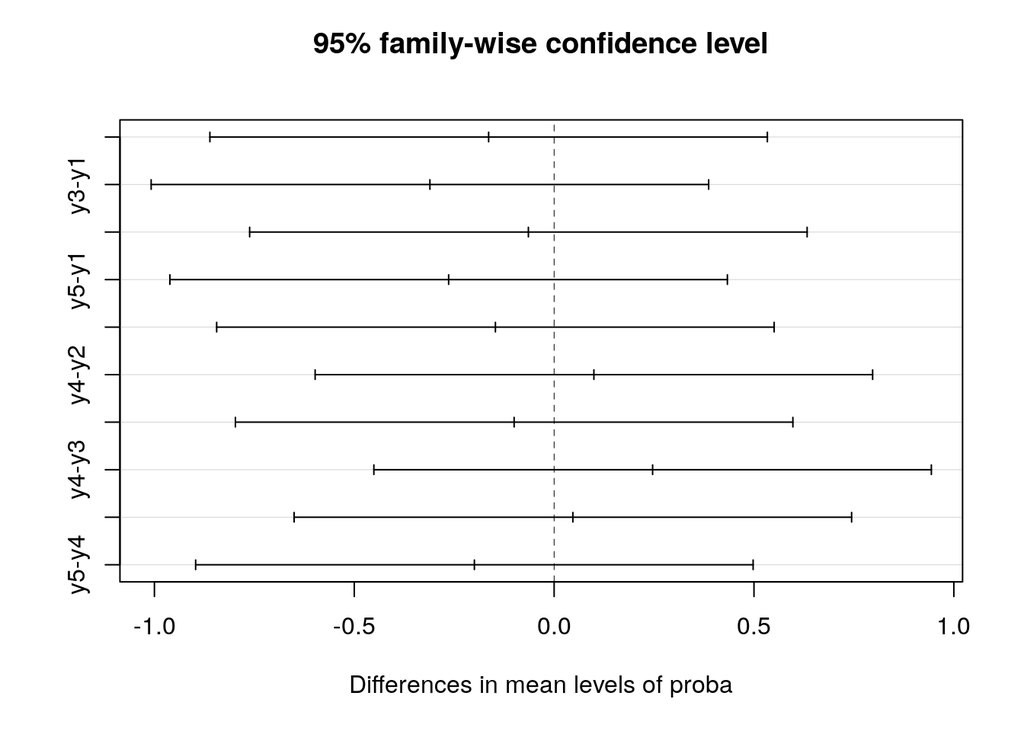

```r
plot(Tukey_res)
```

Powtórz testy dla danych, w których nie ma równości wartości średnich w poszczególnych próbach:

```r
n = 25; mi = 20; sigma = 1; al_2 = 1 # lub 2 lub 4
y1 = rnorm(n, mi, sigma)
y2 = rnorm(n, mi, sigma) + al_2
y3 = rnorm(n, mi, sigma)
y4 = rnorm(n, mi, sigma)
y5 = rnorm(n, mi, sigma)
```

Wygeneruj dane, gdy próby mają różne długości:

```r
n = 25; mi = 20; sigma = 1; al_4 = -2
y1 = rnorm(n, mi, sigma)
y2 = rnorm(n+1, mi, sigma)
y3 = rnorm(n+2, mi, sigma)
y4 = rnorm(n+3, mi, sigma) + al_4
y5 = rnorm(n+4, mi, sigma)
dane_anova = data.frame( dane = c(y1, y2, y3, y4, y5),
proba = rep( c("y1", "y2", "y3", "y4", "y5"),
             times = c(length(y1), length(y2), length(y3), length(y4), length(y5))) )
```

Powtórz wcześniej przeprowadzane testy dot. analizy wariancji dla powyższych danych.

# Przykład 2 – regresja liniowa

Wygeneruj dane zgodnie z poniższymi komendami:

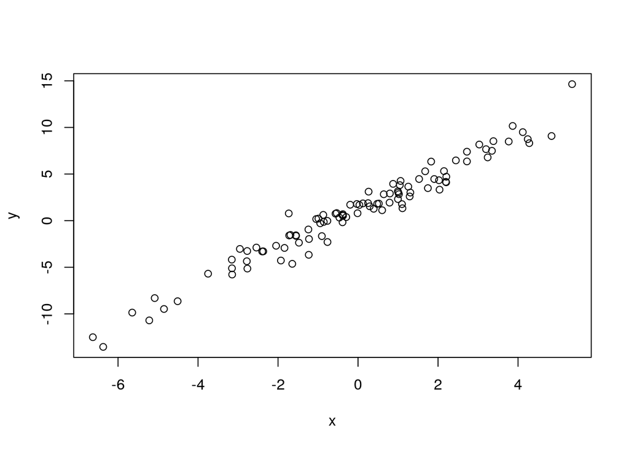

```r
n = 100; mi = 0; sigma = 2
x = rnorm(n, mi, sigma)
e = rnorm(n, 0, 1)
b0 = 1; b1 = 2
y = b1*x + b0 + e
plot(x, y)
```

Wyznacz parametry prostej regresji y = b1*x + b0 i współczynnik determinacji $R^2$:

```r
b1_est = (mean(x*y) - mean(x)*mean(y)) / (mean(x^2)-(mean(x))^2)
b0_est = mean(y) - b1_est*mean(x)
y_est = b1_est*x + b0_est
R2 = 1 - sum((y - y_est)^2)/sum((y - mean(y))^2)
```

Nanieś na rysunek prostą regresji:

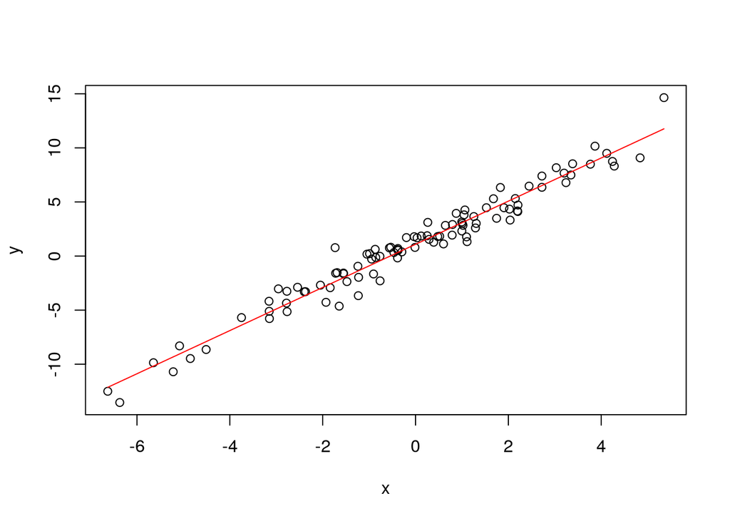

```r
plot(x, y)
arg = c(min(x), max(x))
out = b1_est*arg + b0_est
lines(arg, out, col = 'red')
```

To samo wykonaj za pomocą funkcji lm:

```r
lm_res = lm(y~x)
summary(lm_res)
```

```
##
## Call:
## lm(formula = y ~ x)
##
## Residuals:
##     Min      1Q  Median      3Q     Max
## -2.4402 -0.7147  0.1357  0.6929  3.1424
##
## Coefficients:
##             Estimate Std. Error t value Pr(>|t|)
## (Intercept)  1.08945    0.10252   10.63   <2e-16 ***
## x            1.99441    0.04127   48.32   <2e-16 ***
## ---
## Signif. codes:  0 '***' 0.001 '**' 0.01 '*' 0.05 '.' 0.1 ' ' 1
##
## Residual standard error: 1.025 on 98 degrees of freedom
## Multiple R-squared:  0.9597, Adjusted R-squared:  0.9593
## F-statistic:  2335 on 1 and 98 DF,  p-value: < 2.2e-16
```

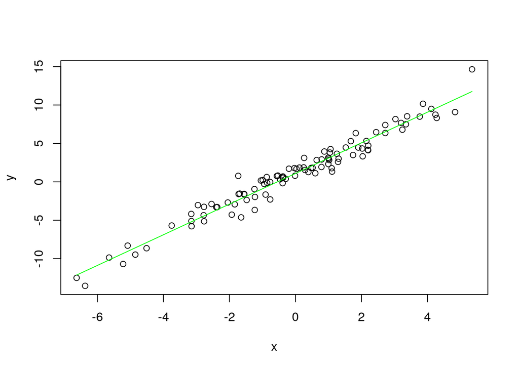

```r
arg = c(min(x), max(x))
out = coef(lm_res)[2]*arg + coef(lm_res)[1]
plot(x, y)
lines(arg, out, col = 'green')
```

Wyznacz parametry prostej regresji x = c1*y + c0 i nanieś ją na wykres z danymi:

```r
plot(x, y)
lines(arg, out, col = 'green')
lm_res = lm(x~y)
summary(lm_res)
```

```
##
## Call:
## lm(formula = x ~ y)
##
## Residuals:
##      Min       1Q   Median       3Q      Max
## -1.57893 -0.31844 -0.08401  0.28837  1.11099
##
## Coefficients:
##              Estimate Std. Error t value Pr(>|t|)
## (Intercept) -0.527237   0.051201  -10.30   <2e-16 ***
## y            0.481205   0.009958   48.32   <2e-16 ***
## ---
## Signif. codes:  0 '***' 0.001 '**' 0.01 '*' 0.05 '.' 0.1 ' ' 1
##
## Residual standard error: 0.5034 on 98 degrees of freedom
## Multiple R-squared:  0.9597, Adjusted R-squared:  0.9593
## F-statistic:  2335 on 1 and 98 DF,  p-value: < 2.2e-16
```

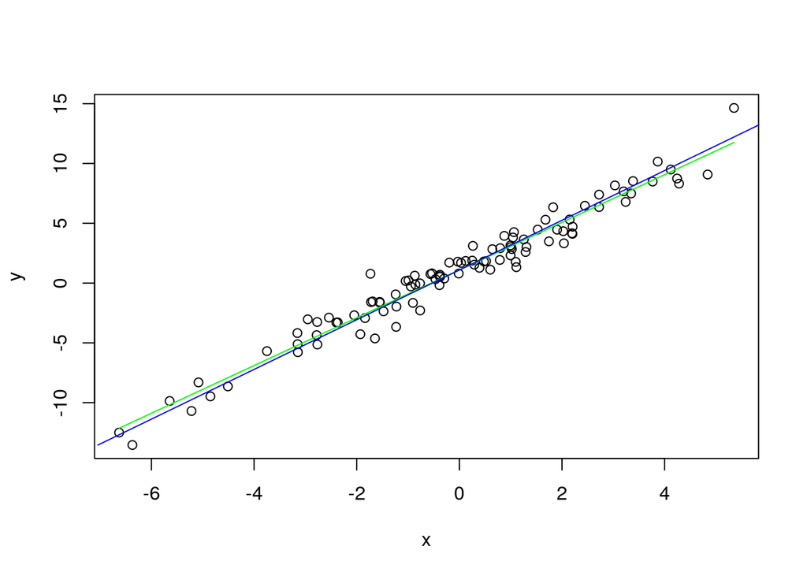

```r
arg = c(min(y), max(y))
out = coef(lm_res)[2]*arg + coef(lm_res)[1]
lines(out, arg, col = 'blue')
```

# Przykład 3 – regresja, przyp. wielowym.

Wygeneruj dane zgodnie z poniższymi komendami:

```r
n = 100
x0 = rep(1, n)
x1 = (1:n)/n
x2 = sin(1:n)
x3 = runif(n, -1, 1)
x = cbind(x0, x1, x2, x3)
b = c(1, -2, 3, -1)
e = rnorm(n, 0, 0.5)
y = x%*%b + e
```

Narysuj zmienną y:

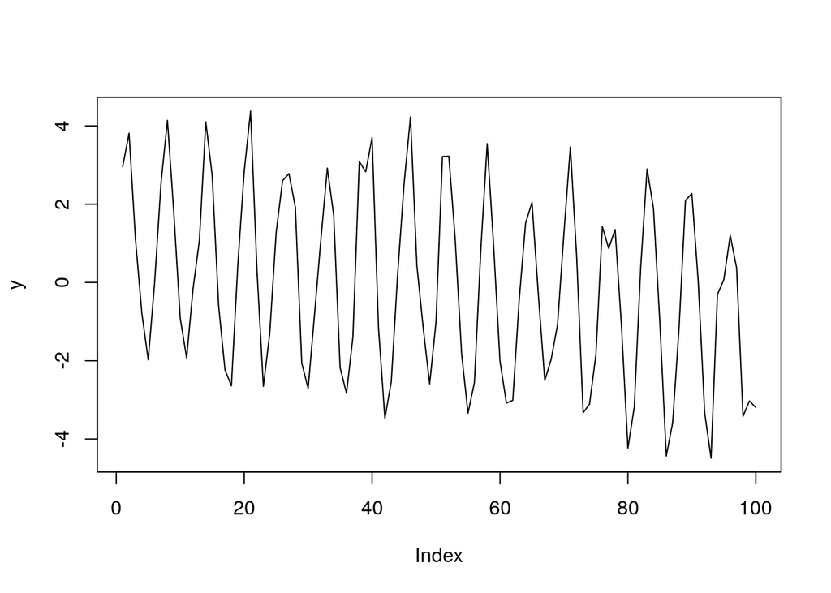

```r
plot(y, type = 'l')
```

Wyznacz parametry modelu korzystając z metody regresji liniowej:

```r
lm_res = lm(y ~ 1 + x1 + x2 + x3)
summary(lm_res)
```

```
##
## Call:
## lm(formula = y ~ 1 + x1 + x2 + x3)
##
## Residuals:
##     Min      1Q  Median      3Q     Max
## -1.0651 -0.3767  0.0132  0.3836  1.1799
##
## Coefficients:
##             Estimate Std. Error t value Pr(>|t|)
## (Intercept)  0.94256    0.09574   9.845  3.2e-16 ***
## x1          -1.97749    0.16471 -12.006  < 2e-16 ***
## x2           3.06674    0.06692  45.825  < 2e-16 ***
## x3          -0.82319    0.08030 -10.252  < 2e-16 ***
## ---
## Signif. codes:  0 '***' 0.001 '**' 0.01 '*' 0.05 '.' 0.1 ' ' 1
##
## Residual standard error: 0.4739 on 96 degrees of freedom
## Multiple R-squared:  0.9621, Adjusted R-squared:  0.9609
## F-statistic: 811.7 on 3 and 96 DF,  p-value: < 2.2e-16
```

Sprawdź jaki jest wynik wywołania linii:

```r
lm_res = lm(y ~ x0 + x1 + x2 + x3 - 1)
summary(lm_res)
```

```
##
## Call:
## lm(formula = y ~ x0 + x1 + x2 + x3 - 1)
##
## Residuals:
##     Min      1Q  Median      3Q     Max
## -1.0651 -0.3767  0.0132  0.3836  1.1799
##
## Coefficients:
##    Estimate Std. Error t value Pr(>|t|)
## x0  0.94256    0.09574   9.845  3.2e-16 ***
## x1 -1.97749    0.16471 -12.006  < 2e-16 ***
## x2  3.06674    0.06692  45.825  < 2e-16 ***
## x3 -0.82319    0.08030 -10.252  < 2e-16 ***
## ---
## Signif. codes:  0 '***' 0.001 '**' 0.01 '*' 0.05 '.' 0.1 ' ' 1
##
## Residual standard error: 0.4739 on 96 degrees of freedom
## Multiple R-squared:  0.9621, Adjusted R-squared:  0.9605
## F-statistic: 609.2 on 4 and 96 DF,  p-value: < 2.2e-16
```

Wartości estymat parametrów modelu można obliczyć w następujący sposób:

```r
b_est = solve(t(x)%*%x)%*%t(x)%*%y
```

# Pliki z danymi ze strony bossa.pl

- [Kursy spółek giełdowych](http://www.galera.ii.pw.edu.pl/~kjedrze1/Lab4/mstall.zip)
- [Kursy indeksów giełd zagranicznych](http://www.galera.ii.pw.edu.pl/~kjedrze1/Lab4/mstzgr.zip)
- [Kursy walut](http://www.galera.ii.pw.edu.pl/~kjedrze1/Lab4/mstnbp.zip)

# Wczytanie danych z plików .mst

Pomocnicza funkcja wczytująca dane z plików .mst:

```r
wczytaj_mst = function(plik_zip, plik_mst) {
  unzip(plik_zip, plik_mst)
  dane = read.csv(plik_mst)
  names(dane) = c('ticker', 'date', 'open', 'high', 'low', 'close', 'vol')
  dane$date = as.Date.character(dane$date,format = '%Y%m%d')
  dane
}
```

Przykład użycia:

```r
dane = wczytaj_mst('mstall.zip', 'KGHM.mst')
```

# Zadanie 1

Korzystając z metod analizy wariancji, dla wybranej spółki notowanej na GPW zweryfikuj hipotezę o równości wartości średnich procentowych zmian cen zamknięcia

- w ostatnich sześciu miesiącach (od listopada do kwietnia),
- w ostatnich trzech miesiącach (od lutego do kwietnia).

Wskazówki:

- obliczenie procentowych zmian cen zamknięcia:

```r
  dane$close_ch= with(dane, c(NA,100*diff(close))/close)
```

- przykładowy sposób wczytania danych dot. np. stycznia 2017:

```r
y1 = with(dane, close_ch[format(date, '%Y-%m') == '2017-01'])
```

# Zadanie 2

Korzystając z regresji liniowej wyznacz zależność indeksu WIG20 od kursów zamknięcia spółek: ASSECO, ENERGA, EUROCASH, ORANGE, PKNORLEN, PKOBP, PZU, PEKAO dla danych z roku 2017, oceń istotność poszczególnych zmiennych objaśniających w tak skonstruowanym modelu, przeprowadź analogiczne analizy w przypadku uwzględnienia w modelu mniejszej ilości spółek, np.: PKNORLEN, PKOBP, PZU, PEKAO.

# Zadanie 3

Korzystając z regresji liniowej:

- zbadaj zależności pomiędzy kursami walut USD, EUR, GBP, CHF dla danych z roku 2017, np. zależność kursu CHF od pozostałych ww. walut; wykorzystaj dane z pliku mstnbp.zip, zbadaj zależności pomiędzy indeksami DJIA, NIKKEI, FT-SE100, DAX, WIG20 dla danych z roku 2017, np. zależność indeksu DAX od pozostałych ww. indeksów; wykorzystaj dane z pliku mstzgr.zip,
- zbadaj zależności pomiędzy kursami walut USD, EUR, a indeksami giełdowymi DJIA, NIKKEI, FT-SE100, DAX, WIG20.

Uwaga: Daty notowań w różnych krajach mogą różnić się. Sposób radzenia sobie z tą niedogodnością:

- Stworzenie podramek, np. dla DJIA:

```r
dane = wczytaj_mst('mstzgr.zip', 'DJIA.mst')
DJIA_df = subset(dane, format(date, '%Y') == '2017', select =c('date', 'close'))
names(DJIA_df) = c('date', 'DJIA')
dane = wczytaj_mst('mstzgr.zip', 'FT-SE100.mst')
FT_SE100_df = subset(dane, format(date, '%Y') == '2017', select =c('date', 'close'))
names(FT_SE100_df) = c('date', 'FT_SE100')
dane = wczytaj_mst('mstzgr.zip', 'NIKKEI.mst')
NIKKEI_df = subset(dane, format(date, '%Y') == '2017', select =c('date', 'close'))
names(NIKKEI_df) = c('date', 'NIKKEI')
```

- Połączenie danych:

```r
ALL_df = merge(DJIA_df, NIKKEI_df, by = 'date')
ALL_df = merge(ALL_df, FT_SE100_df, by = 'date')
```

# Zadanie 4

W poniższej tabeli przedstawiona jest długość drogi hamowania y w zależności od prędkości pojazdu v.

| v (km/h) | y (m) |
| --- | --- |
| 33.0 | 4.7 |
| 33.0 | 4.1 |
| 49.1 | 10.3 |
| 65.2 | 22.3 |
| 78.5 | 33.4 |
| 93.0 | 44.4 |

Dopasuj liniowe zależności opisujące długość drogi y oraz pierwiastek tej długości y w funkcji prędkości v.

Nanieś odpowiednie linie przedstawiające te zależności na rysunek z zarejestrowanymi danymi.

Która z liniowych zależności jest bardziej zgodna z danymi?

# Zadanie 5

Plik oldfaithful.txt zawiera czasy erupcji pewnego gejzeru oraz następujące po nich odstępy czasu do kolejnej erupcji (wszystkie czasy podane są w minutach), które zostały zarejestrowane w ciągu ośmiu kolejnych dni.

Na płaszczyźnie xy (x – czas erupcji, y – odstęp) zaznacz punkty odpowiadające danym. Metodą regresji liniowej dopasuj do nich prostą.

Oszacuj czas, który upłynie do kolejnej erupcji gejzeru, jeśli poprzednia erupcja trwała 2 min. Oszacuj odchylenie standardowe błędu z jakim został wyznaczony ten czas. Powtórz powyższy punkt przy założeniu, że erupcja trwała 4 min.